```python
import sys
sys.version
```

```
'3.4.5 |Continuum Analytics, Inc.| (default, Jul  2 2016, 17:47:57) \n[GCC 4.2.1 Compatible Apple LLVM 4.2 (clang-425.0.28)]'
```

# First, I am going to read the largest files (Master, Batting, Pitching, Fielding) and explore them a bit to understand the data at hand. I also read through the ReadME file to understand all the stats included in the file.

```python
import numpy as np
import pandas as pd

batting = pd.read_csv("/Users/marcmaybaum/Desktop/Education/Udacity/Data_Analyst_Nanodegree/Project_2/Baseball_Stats/Batting.csv")

fielding = pd.read_csv("/Users/marcmaybaum/Desktop/Education/Udacity/Data_Analyst_Nanodegree/Project_2/Baseball_Stats/Fielding.csv")

pitching = pd.read_csv("/Users/marcmaybaum/Desktop/Education/Udacity/Data_Analyst_Nanodegree/Project_2/Baseball_Stats/Pitching.csv")

master = pd.read_csv("/Users/marcmaybaum/Desktop/Education/Udacity/Data_Analyst_Nanodegree/Project_2/Baseball_Stats/Master.csv")
```

## Checking out each dataframe and the stats contained in each file

```python
# batting.head(5)
# fielding.head(5)
# pitching.head(5)
# master.head(5)
```

```python
# Testing batting

# batting_post = batting[batting['yearID'] > 1949.0]
# batting_groupID = batting_post.groupby('playerID').sum()
# print(batting_groupID['AB'].mean())

# batting_groupID = batting.groupby('playerID').sum()
# print(batting_groupID['H'].mean())
```

```python
# batting = batting.groupby('playerID')
batting.describe()
```

|  | yearID | stint | G | AB | R | H | 2B | 3B | HR | RBI | SB | CS | BB | SO | IBB | HBP | SH | SF | GIDP |
| --- | --- | --- | --- | --- | --- | --- | --- | --- | --- | --- | --- | --- | --- | --- | --- | --- | --- | --- | --- |
| count | 102816.000000 | 102816.000000 | 102816.000000 | 102816.000000 | 102816.000000 | 102816.000000 | 102816.000000 | 102816.000000 | 102816.000000 | 102392.000000 | 101516.000000 | 79360.000000 | 102816.000000 | 94978.000000 | 66251.000000 | 100006.000000 | 96478.000000 | 66782.000000 | 76706.000000 |
| mean | 1964.262313 | 1.077838 | 51.343439 | 141.905511 | 18.815544 | 37.139930 | 6.289167 | 1.293252 | 2.813599 | 17.003975 | 2.976821 | 1.226008 | 13.067207 | 20.529712 | 1.105870 | 1.056057 | 2.299540 | 1.054101 | 2.981018 |
| std | 38.856297 | 0.284366 | 47.121658 | 184.654492 | 28.242983 | 52.603757 | 9.662468 | 2.645770 | 6.304919 | 26.352011 | 7.717174 | 2.747377 | 20.746460 | 28.328542 | 2.780187 | 2.276251 | 4.241095 | 1.961732 | 4.735153 |
| min | 1871.000000 | 1.000000 | 1.000000 | 0.000000 | 0.000000 | 0.000000 | 0.000000 | 0.000000 | 0.000000 | 0.000000 | 0.000000 | 0.000000 | 0.000000 | 0.000000 | 0.000000 | 0.000000 | 0.000000 | 0.000000 | 0.000000 |
| 25% | 1934.000000 | 1.000000 | 13.000000 | 4.000000 | 0.000000 | 0.000000 | 0.000000 | 0.000000 | 0.000000 | 0.000000 | 0.000000 | 0.000000 | 0.000000 | 1.000000 | 0.000000 | 0.000000 | 0.000000 | 0.000000 | 0.000000 |
| 50% | 1973.000000 | 1.000000 | 34.000000 | 49.000000 | 4.000000 | 9.000000 | 1.000000 | 0.000000 | 0.000000 | 3.000000 | 0.000000 | 0.000000 | 3.000000 | 9.000000 | 0.000000 | 0.000000 | 0.000000 | 0.000000 | 0.000000 |
| 75% | 1998.000000 | 1.000000 | 80.000000 | 231.000000 | 27.000000 | 58.000000 | 9.000000 | 1.000000 | 2.000000 | 24.000000 | 2.000000 | 1.000000 | 18.000000 | 29.000000 | 1.000000 | 1.000000 | 3.000000 | 1.000000 | 4.000000 |
| max | 2016.000000 | 5.000000 | 165.000000 | 716.000000 | 192.000000 | 262.000000 | 67.000000 | 36.000000 | 73.000000 | 191.000000 | 138.000000 | 42.000000 | 232.000000 | 223.000000 | 120.000000 | 51.000000 | 67.000000 | 19.000000 | 36.000000 |

```python
fielding.describe()
```

|  | yearID | stint | G | GS | InnOuts | PO | A | E | DP | PB | WP | SB | CS | ZR |
| --- | --- | --- | --- | --- | --- | --- | --- | --- | --- | --- | --- | --- | --- | --- |
| count | 136815.000000 | 136815.000000 | 136815.000000 | 85273.000000 | 85273.000000 | 136815.000000 | 136814.000000 | 136813.000000 | 136814.000000 | 11230.000000 | 4189.000000 | 6138.000000 | 6138.000000 | 4189.000000 |
| mean | 1961.653349 | 1.076812 | 35.445792 | 26.680626 | 716.201693 | 83.385469 | 35.324265 | 3.859282 | 7.290058 | 5.147996 | 11.772977 | 24.859726 | 12.005865 | 0.703032 |
| std | 40.949885 | 0.282308 | 41.482180 | 40.731792 | 1067.250667 | 186.285168 | 79.618300 | 7.962017 | 19.616904 | 9.078281 | 12.249974 | 25.714221 | 13.155354 | 1.394882 |
| min | 1871.000000 | 1.000000 | 0.000000 | 0.000000 | 0.000000 | 0.000000 | 0.000000 | 0.000000 | 0.000000 | 0.000000 | 0.000000 | 0.000000 | 0.000000 | 0.000000 |
| 25% | 1928.000000 | 1.000000 | 5.000000 | 0.000000 | 58.000000 | 2.000000 | 1.000000 | 0.000000 | 0.000000 | 0.000000 | 2.000000 | 4.000000 | 1.000000 | 0.000000 |
| 50% | 1972.000000 | 1.000000 | 19.000000 | 7.000000 | 226.000000 | 10.000000 | 7.000000 | 1.000000 | 1.000000 | 2.000000 | 8.000000 | 17.000000 | 8.000000 | 0.000000 |
| 75% | 1997.000000 | 1.000000 | 48.000000 | 32.000000 | 752.000000 | 75.000000 | 27.000000 | 4.000000 | 3.000000 | 6.000000 | 19.000000 | 39.000000 | 19.000000 | 1.000000 |
| max | 2016.000000 | 5.000000 | 165.000000 | 164.000000 | 4469.000000 | 1846.000000 | 641.000000 | 119.000000 | 194.000000 | 105.000000 | 69.000000 | 155.000000 | 89.000000 | 15.000000 |

```python
pitching.describe()
# list(pitching)
```

|  | yearID | stint | W | L | G | GS | CG | SHO | SV | IPouts | ... | IBB | WP | HBP | BK | BFP | GF | R | SH | SF | GIDP |
| --- | --- | --- | --- | --- | --- | --- | --- | --- | --- | --- | --- | --- | --- | --- | --- | --- | --- | --- | --- | --- | --- |
| count | 44963.000000 | 44963.000000 | 44963.000000 | 44963.000000 | 44963.000000 | 44963.000000 | 44963.000000 | 44963.000000 | 44963.000000 | 44963.000000 | ... | 30388.000000 | 44830.000000 | 44405.000000 | 44963.000000 | 44724.000000 | 44830.000000 | 44963.000000 | 12063.000000 | 12063.000000 | 12061.000000 |
| mean | 1968.670062 | 1.079643 | 4.715744 | 4.715722 | 23.681761 | 9.485488 | 3.151035 | 0.448591 | 1.504793 | 253.872139 | ... | 2.411379 | 2.528575 | 2.266096 | 0.301604 | 343.312181 | 6.345260 | 43.021773 | 2.141922 | 1.878388 | 5.322610 |
| std | 37.569499 | 0.284834 | 5.813410 | 4.988846 | 18.493488 | 12.283920 | 7.081844 | 1.109742 | 4.991518 | 257.330446 | ... | 2.772648 | 3.425706 | 2.998881 | 0.755523 | 348.758261 | 9.993949 | 43.245812 | 2.710191 | 2.121352 | 5.990178 |
| min | 1871.000000 | 1.000000 | 0.000000 | 0.000000 | 1.000000 | 0.000000 | 0.000000 | 0.000000 | 0.000000 | 0.000000 | ... | 0.000000 | 0.000000 | 0.000000 | 0.000000 | 0.000000 | 0.000000 | 0.000000 | 0.000000 | 0.000000 | 0.000000 |
| 25% | 1941.000000 | 1.000000 | 0.000000 | 1.000000 | 7.000000 | 0.000000 | 0.000000 | 0.000000 | 0.000000 | 49.000000 | ... | 0.000000 | 0.000000 | 0.000000 | 0.000000 | 64.000000 | 0.000000 | 11.000000 | 0.000000 | 0.000000 | 1.000000 |
| 50% | 1978.000000 | 1.000000 | 2.000000 | 3.000000 | 21.000000 | 3.000000 | 0.000000 | 0.000000 | 0.000000 | 167.000000 | ... | 2.000000 | 1.000000 | 1.000000 | 0.000000 | 227.000000 | 3.000000 | 28.000000 | 1.000000 | 1.000000 | 3.000000 |
| 75% | 2001.000000 | 1.000000 | 7.000000 | 8.000000 | 35.000000 | 17.000000 | 3.000000 | 0.000000 | 1.000000 | 393.000000 | ... | 4.000000 | 4.000000 | 3.000000 | 0.000000 | 535.000000 | 8.000000 | 67.000000 | 3.000000 | 3.000000 | 8.000000 |
| max | 2016.000000 | 4.000000 | 59.000000 | 48.000000 | 106.000000 | 75.000000 | 75.000000 | 16.000000 | 62.000000 | 2040.000000 | ... | 23.000000 | 63.000000 | 41.000000 | 16.000000 | 2906.000000 | 84.000000 | 519.000000 | 21.000000 | 14.000000 | 40.000000 |

8 rows × 27 columns

```python
master = master[['playerID', 'nameFirst', 'nameLast']]
master.head(5)
```

|  | playerID | nameFirst | nameLast |
| --- | --- | --- | --- |
| 0 | aardsda01 | David | Aardsma |
| 1 | aaronha01 | Hank | Aaron |
| 2 | aaronto01 | Tommie | Aaron |
| 3 | aasedo01 | Don | Aase |
| 4 | abadan01 | Andy | Abad |

# After looking through the data, I've decided I want to find out who were the best catchers to play the game. To start, I'm going to explore the Hall of Fame data to find out who they have identified as some of the best.

### Reading & looking at the HOF data

```python
hof = pd.read_csv("/Users/marcmaybaum/Desktop/Education/Udacity/Data_Analyst_Nanodegree/Project_2/Baseball_Stats/HallOfFame.csv")

# print(hof)
```

### Adding position to HOF data so I can find the best catchers

```python
fielding_pos = fielding[['playerID', 'POS']]
fielding_pos = fielding_pos[(fielding_pos['POS'] == 'C')]
fielding_pos = fielding_pos.drop_duplicates()

hof = hof.merge(fielding_pos, on='playerID', how='left', left_index = True)

# print(hof)
```

### Creating a segment of HOF data only for Catchers inducted to the HOF as a player

```python
hof_catcher = (hof[(hof['POS'] == 'C') & (hof['inducted'] == 'Y') & (hof['category'] =='Player')])

# hof_catcher = hof_catcher.drop_duplicates()

hof_catcher.shape
hof_catcher.head()
```

|  | playerID | yearid | votedBy | ballots | needed | votes | inducted | category | needed_note | POS |
| --- | --- | --- | --- | --- | --- | --- | --- | --- | --- | --- |
| 9 | ansonca01 | 1939 | Old Timers | NaN | NaN | NaN | Y | Player | NaN | C |
| 2419 | ewingbu01 | 1939 | Old Timers | NaN | NaN | NaN | Y | Player | NaN | C |
| 14690 | bresnro01 | 1945 | Old Timers | NaN | NaN | NaN | Y | Player | NaN | C |
| 13708 | duffyhu01 | 1945 | Old Timers | NaN | NaN | NaN | Y | Player | NaN | C |
| 2016 | kellyki01 | 1945 | Old Timers | NaN | NaN | NaN | Y | Player | NaN | C |

### Find out these players names by merging with master

```python
hof_catcher = hof_catcher.merge(master, on = 'playerID', how='left', left_index = True)

print(hof_catcher)
```

```
        playerID  yearid     votedBy  ballots  needed  votes inducted  \
389    ansonca01    1939  Old Timers      NaN     NaN    NaN        Y
5144   ewingbu01    1939  Old Timers      NaN     NaN    NaN        Y
1856   bresnro01    1945  Old Timers      NaN     NaN    NaN        Y
4687   duffyhu01    1945  Old Timers      NaN     NaN    NaN        Y
8968   kellyki01    1945  Old Timers      NaN     NaN    NaN        Y
12909  orourji01    1945  Old Timers      NaN     NaN    NaN        Y
2864   chancfr01    1946  Old Timers      NaN     NaN    NaN        Y
3188   cochrmi01    1947       BBWAA    161.0   121.0  128.0        Y
5647    foxxji01    1951       BBWAA    226.0   170.0  179.0        Y
4357   dickebi01    1954       BBWAA    252.0   189.0  202.0        Y
7230   hartnga01    1955       BBWAA    251.0   189.0  195.0        Y
15304  schalra01    1955    Veterans      NaN     NaN    NaN        Y
2486   camparo01    1969       BBWAA    340.0   255.0  270.0        Y
1653   boudrlo01    1970       BBWAA    300.0   225.0  232.0        Y
```

[output cut: 36 more lines]

# Now, that I've identified Catchers in HOF, I want to learn what their career numbers were for both offense & defense (data found in batting & fielding files) and how their production compares to all catchers to understand why they were voted into the HOF.

### Only defensive data I want is for when the player played as a catcher.

### Defensive data includes data for every position player played during the regular season.

```python
# Take playerIDs from hof_catcher & find them in fielding & batting files

hof_catcher_playerID = hof_catcher['playerID']

offense_hof_c = batting[batting.playerID.isin(hof_catcher_playerID)]

fielding_catcher = fielding[fielding['POS'] == 'C']

defense_hof_c = fielding_catcher[fielding_catcher.playerID.isin(hof_catcher_playerID)]

offense_defense_hof_c = offense_hof_c.merge(defense_hof_c, on=['playerID', 'yearID', 'teamID'], how='left', left_index=False, right_index=False, suffixes=('_batting','_fielding'))

offense_defense_hof_c.to_csv("/Users/marcmaybaum/Desktop/Education/Udacity/Data_Analyst_Nanodegree/Project_2/Baseball_Stats/OffenseDefense_HOF_C.csv")

offense_defense_hof_c.columns.values
```

```
array(['playerID', 'yearID', 'stint_batting', 'teamID', 'lgID_batting',
       'G_batting', 'AB', 'R', 'H', '2B', '3B', 'HR', 'RBI', 'SB_batting',
       'CS_batting', 'BB', 'SO', 'IBB', 'HBP', 'SH', 'SF', 'GIDP',
       'stint_fielding', 'lgID_fielding', 'POS', 'G_fielding', 'GS',
       'InnOuts', 'PO', 'A', 'E', 'DP', 'PB', 'WP', 'SB_fielding',
       'CS_fielding', 'ZR'], dtype=object)
```

### After finding the playerIDs from the hof_catcher file and selecting only the defensive stats, I added first and last names to each playerID, formatted the data type of each column to be consistent (float for numbers), and replaced NaN with 0 values where applicable.

```python
# Merge these files on playerID, yearID & teamID to have a master catcher offense/defense file

offense_defense_hof_c = offense_defense_hof_c.merge(master, on = 'playerID', how='left', left_index = True)

# Formatting all data types in dataframe

offense_defense_hof_c.dtypes
offense_defense_hof_c = offense_defense_hof_c.astype('float', raise_on_error = False)

# Filling all NaN with 0 so I can create measurements

offense_defense_hof_c = offense_defense_hof_c.fillna(0)

offense_defense_hof_c.to_csv("/Users/marcmaybaum/Desktop/Education/Udacity/Data_Analyst_Nanodegree/Project_2/Baseball_Stats/OffenseDefense_C.csv")
```

```python
offense_defense_hof_c.head()
```

|  | playerID | yearID | stint_batting | teamID | lgID_batting | G_batting | AB | R | H | 2B | ... | A | E | DP | PB | WP | SB_fielding | CS_fielding | ZR | nameFirst | nameLast |
| --- | --- | --- | --- | --- | --- | --- | --- | --- | --- | --- | --- | --- | --- | --- | --- | --- | --- | --- | --- | --- | --- |
| 389 | ansonca01 | 1871.0 | 1.0 | RC1 | 0 | 25.0 | 120.0 | 29.0 | 39.0 | 11.0 | ... | 0.0 | 8.0 | 0.0 | 0.0 | 0.0 | 0.0 | 0.0 | 0.0 | Cap | Anson |
| 18335 | whitede01 | 1871.0 | 1.0 | CL1 | 0 | 29.0 | 146.0 | 40.0 | 47.0 | 6.0 | ... | 20.0 | 34.0 | 3.0 | 0.0 | 0.0 | 0.0 | 0.0 | 0.0 | Deacon | White |
| 389 | ansonca01 | 1872.0 | 1.0 | PH1 | 0 | 46.0 | 217.0 | 60.0 | 90.0 | 10.0 | ... | 0.0 | 0.0 | 0.0 | 0.0 | 0.0 | 0.0 | 0.0 | 0.0 | Cap | Anson |
| 12909 | orourji01 | 1872.0 | 1.0 | MID | 0 | 23.0 | 101.0 | 25.0 | 31.0 | 4.0 | ... | 5.0 | 11.0 | 1.0 | 0.0 | 0.0 | 0.0 | 0.0 | 0.0 | Jim | O'Rourke |
| 18335 | whitede01 | 1872.0 | 1.0 | CL1 | 0 | 22.0 | 109.0 | 21.0 | 37.0 | 2.0 | ... | 14.0 | 10.0 | 5.0 | 0.0 | 0.0 | 0.0 | 0.0 | 0.0 | Deacon | White |

5 rows × 39 columns

## After completing data cleansing steps above, I can find out career averages for each of these stats, when appropriate.

```python
# First step is looking into the data in the ReadME file & researching baseball stats
# https://en.wikipedia.org/wiki/Baseball_statistics#Batting_statistics

playerID_od_c = offense_defense_hof_c.groupby(['playerID','nameFirst', 'nameLast']).sum()

# playerID_od_c.head()
```

```python
playerID_od_c = playerID_od_c[['G_batting', 'AB', 'R', 'H', '2B', '3B', 'HR', 'RBI', 'SB_batting', 'CS_batting', 'BB', 'SO', \
                           'IBB', 'HBP', 'SH', 'SF', 'GIDP', 'G_fielding', 'GS', 'InnOuts', 'PO', 'A', 'E', 'DP', 'PB', \
                           'WP', 'SB_fielding', 'CS_fielding', 'ZR']]
```

### After aggregating the data by playerID, first name, and last name, I am adding some common stats not available in the dataset to analyze players - Batting Average (AVG), On Base Percentage (OBP), Slugging Percentage (SLG), and On Base Plus Slugging Percentage (OBP)

```python
# Batting average formula based on Wikipedia formula
# https://en.wikipedia.org/wiki/Baseball_statistics#Batting_statistics

playerID_od_c['AVG'] = (playerID_od_c['H'])/(playerID_od_c['AB'])

# OBP formula retrieved from
# http://www.baseball-reference.com/bullpen/On_base_percentage

playerID_od_c['OBP'] = (playerID_od_c['BB'] + playerID_od_c['H'] + playerID_od_c['HBP'])/(playerID_od_c['AB'] + playerID_od_c['BB'] \
                                                                                 + playerID_od_c['HBP'] + playerID_od_c['SF'])

# SLG Percentage to weight a hitter's impact to runs scored
# https://en.wikipedia.org/wiki/Slugging_percentage

playerID_od_c['SLG'] = ((playerID_od_c['HR'] * 4) + (playerID_od_c['3B'] * 3) +\
                        (playerID_od_c['2B'] * 2) + \
                        (playerID_od_c['H']-(playerID_od_c['2B'] + playerID_od_c['3B'] + playerID_od_c['HR'])))/\
                        playerID_od_c['AB']

# OPS to find total value of player (OBP + SLG)
# http://m.mlb.com/glossary/standard-stats/on-base-plus-slugging

playerID_od_c['OPS'] = playerID_od_c['SLG'] + playerID_od_c['OBP']

# Writing this to file to read

playerID_od_c.to_csv("/Users/marcmaybaum/Desktop/Education/Udacity/Data_Analyst_Nanodegree/Project_2/Baseball_Stats/OffenseDefenseAgg_C.csv")

print(playerID_od_c)
```

```
                                G_batting       AB       R       H     2B  \
playerID  nameFirst nameLast
ansonca01 Cap       Anson          2523.0  10277.0  1996.0  3418.0  581.0
benchjo01 Johnny    Bench          2158.0   7658.0  1091.0  2048.0  381.0
berrayo01 Yogi      Berra          2120.0   7555.0  1175.0  2150.0  321.0
biggicr01 Craig     Biggio         2850.0  10876.0  1844.0  3060.0  668.0
boudrlo01 Lou       Boudreau       1646.0   6029.0   861.0  1779.0  385.0
bresnro01 Roger     Bresnahan      1446.0   4481.0   682.0  1252.0  218.0
camparo01 Roy       Campanella     1215.0   4205.0   627.0  1161.0  178.0
cartega01 Gary      Carter         2295.0   7971.0  1025.0  2092.0  371.0
chancfr01 Frank     Chance         1287.0   4297.0   797.0  1273.0  200.0
cochrmi01 Mickey    Cochrane       1482.0   5169.0  1041.0  1652.0  333.0
dickebi01 Bill      Dickey         1789.0   6300.0   930.0  1969.0  343.0
duffyhu01 Hugh      Duffy          1737.0   7042.0  1552.0  2282.0  325.0
ewingbu01 Buck      Ewing          1315.0   5363.0  1129.0  1625.0  250.0
ferreri01 Rick      Ferrell        1884.0   6028.0   687.0  1692.0  324.0
fiskca01  Carlton   Fisk           2499.0   8756.0  1276.0  2356.0  421.0
foxxji01  Jimmie    Foxx           2317.0   8134.0  1751.0  2646.0  458.0
hartnga01 Gabby     Hartnett       1990.0   6432.0   867.0  1912.0  396.0
kellyki01 King      Kelly          1455.0   5894.0  1357.0  1813.0  359.0
lombaer01 Ernie     Lombardi       1853.0   5855.0   601.0  1792.0  277.0
orourji01 Jim       O'Rourke       1999.0   8505.0  1729.0  2643.0  465.0
piazzmi01 Mike      Piazza         1912.0   6911.0  1048.0  2127.0  344.0
rodriiv01 Ivan      Rodriguez      2543.0   9592.0  1354.0  2844.0  572.0
schalra01 Ray       Schalk         1762.0   5306.0   579.0  1345.0  199.0
whitede01 Deacon    White          1560.0   6624.0  1140.0  2066.0  268.0

                                   3B     HR     RBI  SB_batting  CS_batting  \
playerID  nameFirst nameLast
ansonca01 Cap       Anson       142.0   97.0  2076.0       276.0        16.0
benchjo01 Johnny    Bench        24.0  389.0  1376.0        68.0        43.0
berrayo01 Yogi      Berra        49.0  358.0  1430.0        30.0        26.0
biggicr01 Craig     Biggio       55.0  291.0  1175.0       414.0       124.0
boudrlo01 Lou       Boudreau     66.0   68.0   789.0        51.0        50.0
bresnro01 Roger     Bresnahan    71.0   26.0   530.0       212.0         3.0
camparo01 Roy       Campanella   18.0  242.0   856.0        25.0        15.0
cartega01 Gary      Carter       31.0  324.0  1225.0        39.0        42.0
chancfr01 Frank     Chance       79.0   20.0   596.0       401.0         0.0
cochrmi01 Mickey    Cochrane     64.0  119.0   832.0        64.0        46.0
dickebi01 Bill      Dickey       72.0  202.0  1209.0        37.0        29.0
```

[output cut: 81 more lines]

```
duffyhu01 Hugh      Duffy       0.449162  0.833618
ewingbu01 Buck      Ewing       0.455715  0.807207
ferreri01 Rick      Ferrell     0.363305  0.741121
fiskca01  Carlton   Fisk        0.456715  0.797409
foxxji01  Jimmie    Foxx        0.609294  1.037568
hartnga01 Gabby     Hartnett    0.488806  0.858402
kellyki01 King      Kelly       0.438242  0.806019
lombaer01 Ernie     Lombardi    0.459949  0.818186
orourji01 Jim       O'Rourke    0.422810  0.775147
piazzmi01 Mike      Piazza      0.545218  0.921719
rodriiv01 Ivan      Rodriguez   0.464033  0.797561
schalra01 Ray       Schalk      0.315680  0.655844
whitede01 Deacon    White       0.391757  0.737999

[24 rows x 33 columns]
```

# After looking at HOF Catchers' career hitting & fielding, I noticed a major discrepancy: Players that played prior to 1950 that were voted in by committees other than the BBWAA have much different statistics than modern players.

# For example, Caught Stealing (CS), Zone Rating (ZR), and Sacrifice Flies (SF) are all statistics of the modern game that are not included in each players data set.

# Because of this, I have decided to remove these players from the data set and to compare players in the modern era that the BBWAA have chosen.

# To read more about this distinction between players' era and how they are voted into the Hall of Fame, see link below.

http://baseballhall.org/news/hall-of-fame-announcements

# Post 1949 & BBWAA HOF Players

```python
# players before 1949 are not included

offense_defense_hof_c = offense_defense_hof_c[(offense_defense_hof_c['yearID'] >= 1949.0)]
```

## Pasting in data from previous code to keep format consistant for Modern Players

```python
# grouping data by playerID

playerID_od_c = offense_defense_hof_c.groupby(['playerID','nameFirst', 'nameLast']).sum()

# playerID_od_c.head()
```

## Removing any partial careers from dataset by filtering ZR Score to be greater than 0 since this measurement doesn't exist for players before 1949

```python
# playerID_od_c.dtypes

playerID_od_c = playerID_od_c[playerID_od_c['ZR'] != 0.0]
print(playerID_od_c)
```

```
                                 yearID  stint_batting  G_batting       AB  \
playerID  nameFirst nameLast
benchjo01 Johnny    Bench       33575.0           17.0     2158.0   7658.0
berrayo01 Yogi      Berra       31305.0           16.0     1905.0   6771.0
biggicr01 Craig     Biggio      39950.0           20.0     2850.0  10876.0
camparo01 Roy       Campanella  17577.0            9.0     1132.0   3926.0
cartega01 Gary      Carter      37677.0           19.0     2295.0   7971.0
fiskca01  Carlton   Fisk        47555.0           24.0     2499.0   8756.0
piazzmi01 Mike      Piazza      35988.0           21.0     1912.0   6911.0
rodriiv01 Ivan      Rodriguez   46038.0           25.0     2543.0   9592.0

                                     R       H     2B    3B     HR     RBI  \
playerID  nameFirst nameLast
benchjo01 Johnny    Bench       1091.0  2048.0  381.0  24.0  389.0  1376.0
berrayo01 Yogi      Berra       1061.0  1917.0  281.0  36.0  331.0  1274.0
biggicr01 Craig     Biggio      1844.0  3060.0  668.0  55.0  291.0  1175.0
camparo01 Roy       Campanella   595.0  1089.0  167.0  15.0  233.0   811.0
cartega01 Gary      Carter      1025.0  2092.0  371.0  31.0  324.0  1225.0
fiskca01  Carlton   Fisk        1276.0  2356.0  421.0  47.0  376.0  1330.0
piazzmi01 Mike      Piazza      1048.0  2127.0  344.0   8.0  427.0  1335.0
rodriiv01 Ivan      Rodriguez   1354.0  2844.0  572.0  51.0  311.0  1332.0

                                ...   InnOuts       PO       A      E     DP  \
playerID  nameFirst nameLast    ...
benchjo01 Johnny    Bench       ...   43465.0   9249.0   850.0   97.0  127.0
berrayo01 Yogi      Berra       ...   22862.0   8154.0   738.0   95.0  163.0
biggicr01 Craig     Biggio      ...   10479.0   2456.0   202.0   30.0   20.0
camparo01 Roy       Campanella  ...   11551.0   6107.0   505.0   76.0   70.0
cartega01 Gary      Carter      ...   52107.0  11785.0  1203.0  121.0  149.0
fiskca01  Carlton   Fisk        ...   55535.0  11369.0  1048.0  155.0  147.0
piazzmi01 Mike      Piazza      ...   40665.0  10844.0   733.0  124.0   88.0
rodriiv01 Ivan      Rodriguez   ...   61044.0  14864.0  1227.0  142.0  158.0

                                   PB     WP  SB_fielding  CS_fielding    ZR
playerID  nameFirst nameLast
benchjo01 Johnny    Bench        94.0  446.0        610.0        469.0  62.0
berrayo01 Yogi      Berra        65.0  123.0        208.0        203.0  10.0
biggicr01 Craig     Biggio       32.0  100.0        434.0        130.0   2.0
camparo01 Roy       Campanella   52.0   93.0         85.0         80.0   4.0
cartega01 Gary      Carter       84.0  464.0       1498.0        810.0  52.0
fiskca01  Carlton   Fisk        129.0  428.0       1302.0        664.0  20.0
piazzmi01 Mike      Piazza      102.0  222.0       1400.0        423.0   6.0
rodriiv01 Ivan      Rodriguez   127.0  394.0        786.0        661.0  59.0

[8 rows x 32 columns]
```

## Recreating AVG, OBP, SLG, and OPS for new data set

```python
playerID_od_c = playerID_od_c[['G_batting', 'AB', 'R', 'H', '2B', '3B', 'HR', 'RBI', 'SB_batting', 'CS_batting', 'BB', 'SO', \
                           'IBB', 'HBP', 'SH', 'SF', 'GIDP', 'G_fielding', 'GS', 'InnOuts', 'PO', 'A', 'E', 'DP', 'PB', \
                           'WP', 'SB_fielding', 'CS_fielding', 'ZR']]

# Batting average formula based on Wikipedia formula
# https://en.wikipedia.org/wiki/Baseball_statistics#Batting_statistics

playerID_od_c['AVG'] = (playerID_od_c['H'])/(playerID_od_c['AB'])

# OBP formula retrieved from
# http://www.baseball-reference.com/bullpen/On_base_percentage

playerID_od_c['OBP'] = (playerID_od_c['BB'] + playerID_od_c['H'] + playerID_od_c['HBP'])/(playerID_od_c['AB'] + playerID_od_c['BB'] \
                                                                                 + playerID_od_c['HBP'] + playerID_od_c['SF'])

# SLG Percentage to weight a hitter's impact to runs scored
# https://en.wikipedia.org/wiki/Slugging_percentage

playerID_od_c['SLG'] = ((playerID_od_c['HR'] * 4) + (playerID_od_c['3B'] * 3) +\
                        (playerID_od_c['2B'] * 2) + \
                        (playerID_od_c['H']-(playerID_od_c['2B'] + playerID_od_c['3B'] + playerID_od_c['HR'])))/\
                        playerID_od_c['AB']

# OPS to find total value of player (OBP + SLG)
# http://m.mlb.com/glossary/standard-stats/on-base-plus-slugging

playerID_od_c['OPS'] = playerID_od_c['SLG'] + playerID_od_c['OBP']

# Writing this to file

playerID_od_c.to_csv("/Users/marcmaybaum/Desktop/Education/Udacity/Data_Analyst_Nanodegree/Project_2/Baseball_Stats/OffenseDefenseAgg_C_1949.csv")

print(playerID_od_c)
```

```
                                G_batting       AB       R       H     2B  \
playerID  nameFirst nameLast
benchjo01 Johnny    Bench          2158.0   7658.0  1091.0  2048.0  381.0
berrayo01 Yogi      Berra          1905.0   6771.0  1061.0  1917.0  281.0
biggicr01 Craig     Biggio         2850.0  10876.0  1844.0  3060.0  668.0
camparo01 Roy       Campanella     1132.0   3926.0   595.0  1089.0  167.0
cartega01 Gary      Carter         2295.0   7971.0  1025.0  2092.0  371.0
fiskca01  Carlton   Fisk           2499.0   8756.0  1276.0  2356.0  421.0
piazzmi01 Mike      Piazza         1912.0   6911.0  1048.0  2127.0  344.0
rodriiv01 Ivan      Rodriguez      2543.0   9592.0  1354.0  2844.0  572.0

                                  3B     HR     RBI  SB_batting  CS_batting  \
playerID  nameFirst nameLast
benchjo01 Johnny    Bench       24.0  389.0  1376.0        68.0        43.0
berrayo01 Yogi      Berra       36.0  331.0  1274.0        27.0        22.0
biggicr01 Craig     Biggio      55.0  291.0  1175.0       414.0       124.0
camparo01 Roy       Campanella  15.0  233.0   811.0        22.0        15.0
cartega01 Gary      Carter      31.0  324.0  1225.0        39.0        42.0
fiskca01  Carlton   Fisk        47.0  376.0  1330.0       128.0        58.0
piazzmi01 Mike      Piazza       8.0  427.0  1335.0        17.0        20.0
rodriiv01 Ivan      Rodriguez   51.0  311.0  1332.0       127.0        64.0

                                  ...        DP     PB     WP  SB_fielding  \
playerID  nameFirst nameLast      ...
benchjo01 Johnny    Bench         ...     127.0   94.0  446.0        610.0
berrayo01 Yogi      Berra         ...     163.0   65.0  123.0        208.0
biggicr01 Craig     Biggio        ...      20.0   32.0  100.0        434.0
camparo01 Roy       Campanella    ...      70.0   52.0   93.0         85.0
cartega01 Gary      Carter        ...     149.0   84.0  464.0       1498.0
fiskca01  Carlton   Fisk          ...     147.0  129.0  428.0       1302.0
piazzmi01 Mike      Piazza        ...      88.0  102.0  222.0       1400.0
rodriiv01 Ivan      Rodriguez     ...     158.0  127.0  394.0        786.0

                                CS_fielding    ZR       AVG       OBP  \
playerID  nameFirst nameLast
benchjo01 Johnny    Bench             469.0  62.0  0.267433  0.341649
berrayo01 Yogi      Berra             203.0  10.0  0.283119  0.349622
biggicr01 Craig     Biggio            130.0   2.0  0.281353  0.363248
camparo01 Roy       Campanella         80.0   4.0  0.277382  0.361298
cartega01 Gary      Carter            810.0  52.0  0.262451  0.334743
fiskca01  Carlton   Fisk              664.0  20.0  0.269073  0.340694
piazzmi01 Mike      Piazza            423.0   6.0  0.307770  0.376501
rodriiv01 Ivan      Rodriguez         661.0  59.0  0.296497  0.333529

                                     SLG       OPS
playerID  nameFirst nameLast
benchjo01 Johnny    Bench       0.475842  0.817492
berrayo01 Yogi      Berra       0.481908  0.831530
biggicr01 Craig     Biggio      0.433156  0.796403
camparo01 Roy       Campanella  0.505604  0.866901
cartega01 Gary      Carter      0.438715  0.773458
fiskca01  Carlton   Fisk        0.456715  0.797409
piazzmi01 Mike      Piazza      0.545218  0.921719
rodriiv01 Ivan      Rodriguez   0.464033  0.797561

[8 rows x 33 columns]
```

```python
playerID_od_c.describe()
```

|  | G_batting | AB | R | H | 2B | 3B | HR | RBI | SB_batting | CS_batting | ... | DP | PB | WP | SB_fielding | CS_fielding | ZR | AVG | OBP | SLG | OPS |
| --- | --- | --- | --- | --- | --- | --- | --- | --- | --- | --- | --- | --- | --- | --- | --- | --- | --- | --- | --- | --- | --- |
| count | 8.000000 | 8.000000 | 8.000000 | 8.000000 | 8.000000 | 8.000000 | 8.000000 | 8.000000 | 8.000000 | 8.00000 | ... | 8.000000 | 8.00000 | 8.000000 | 8.0000 | 8.000000 | 8.000000 | 8.000000 | 8.000000 | 8.000000 | 8.000000 |
| mean | 2161.750000 | 7807.625000 | 1161.750000 | 2191.625000 | 400.625000 | 33.375000 | 335.250000 | 1232.250000 | 105.250000 | 48.50000 | ... | 115.250000 | 85.62500 | 283.750000 | 790.3750 | 430.000000 | 26.875000 | 0.280635 | 0.350160 | 0.475149 | 0.825309 |
| std | 526.338769 | 2087.135901 | 355.262378 | 601.500252 | 157.948398 | 17.095843 | 61.077819 | 182.542167 | 132.522505 | 35.33513 | ... | 51.067882 | 34.57058 | 165.435141 | 551.6738 | 272.059867 | 26.204893 | 0.015324 | 0.015426 | 0.036718 | 0.048102 |
| min | 1132.000000 | 3926.000000 | 595.000000 | 1089.000000 | 167.000000 | 8.000000 | 233.000000 | 811.000000 | 17.000000 | 15.00000 | ... | 20.000000 | 32.00000 | 93.000000 | 85.0000 | 80.000000 | 2.000000 | 0.262451 | 0.333529 | 0.433156 | 0.773458 |
| 25% | 1910.250000 | 6876.000000 | 1042.250000 | 2015.250000 | 328.250000 | 21.750000 | 306.000000 | 1212.500000 | 25.750000 | 21.50000 | ... | 83.500000 | 61.75000 | 117.250000 | 377.5000 | 184.750000 | 5.500000 | 0.268663 | 0.339206 | 0.452215 | 0.797158 |
| 50% | 2226.500000 | 7814.500000 | 1076.000000 | 2109.500000 | 376.000000 | 33.500000 | 327.500000 | 1302.000000 | 53.500000 | 42.50000 | ... | 137.000000 | 89.00000 | 308.000000 | 698.0000 | 446.000000 | 15.000000 | 0.279367 | 0.345635 | 0.469937 | 0.807526 |
| 75% | 2510.000000 | 8965.000000 | 1295.500000 | 2478.000000 | 458.750000 | 48.000000 | 379.250000 | 1332.750000 | 127.250000 | 59.50000 | ... | 151.250000 | 108.25000 | 432.500000 | 1326.5000 | 661.750000 | 53.750000 | 0.286464 | 0.361785 | 0.487832 | 0.840373 |
| max | 2850.000000 | 10876.000000 | 1844.000000 | 3060.000000 | 668.000000 | 55.000000 | 427.000000 | 1376.000000 | 414.000000 | 124.00000 | ... | 163.000000 | 129.00000 | 464.000000 | 1498.0000 | 810.000000 | 62.000000 | 0.307770 | 0.376501 | 0.545218 | 0.921719 |

8 rows × 33 columns

```python
playerID_od_c = playerID_od_c.sort(columns=['HR'], ascending=False)
print (playerID_od_c)
```

```
                                G_batting       AB       R       H     2B  \
playerID  nameFirst nameLast
piazzmi01 Mike      Piazza         1912.0   6911.0  1048.0  2127.0  344.0
benchjo01 Johnny    Bench          2158.0   7658.0  1091.0  2048.0  381.0
fiskca01  Carlton   Fisk           2499.0   8756.0  1276.0  2356.0  421.0
berrayo01 Yogi      Berra          1905.0   6771.0  1061.0  1917.0  281.0
cartega01 Gary      Carter         2295.0   7971.0  1025.0  2092.0  371.0
rodriiv01 Ivan      Rodriguez      2543.0   9592.0  1354.0  2844.0  572.0
biggicr01 Craig     Biggio         2850.0  10876.0  1844.0  3060.0  668.0
camparo01 Roy       Campanella     1132.0   3926.0   595.0  1089.0  167.0

                                  3B     HR     RBI  SB_batting  CS_batting  \
playerID  nameFirst nameLast
piazzmi01 Mike      Piazza       8.0  427.0  1335.0        17.0        20.0
benchjo01 Johnny    Bench       24.0  389.0  1376.0        68.0        43.0
fiskca01  Carlton   Fisk        47.0  376.0  1330.0       128.0        58.0
berrayo01 Yogi      Berra       36.0  331.0  1274.0        27.0        22.0
cartega01 Gary      Carter      31.0  324.0  1225.0        39.0        42.0
rodriiv01 Ivan      Rodriguez   51.0  311.0  1332.0       127.0        64.0
biggicr01 Craig     Biggio      55.0  291.0  1175.0       414.0       124.0
camparo01 Roy       Campanella  15.0  233.0   811.0        22.0        15.0

                                  ...        DP     PB     WP  SB_fielding  \
playerID  nameFirst nameLast      ...
piazzmi01 Mike      Piazza        ...      88.0  102.0  222.0       1400.0
benchjo01 Johnny    Bench         ...     127.0   94.0  446.0        610.0
fiskca01  Carlton   Fisk          ...     147.0  129.0  428.0       1302.0
berrayo01 Yogi      Berra         ...     163.0   65.0  123.0        208.0
cartega01 Gary      Carter        ...     149.0   84.0  464.0       1498.0
rodriiv01 Ivan      Rodriguez     ...     158.0  127.0  394.0        786.0
biggicr01 Craig     Biggio        ...      20.0   32.0  100.0        434.0
camparo01 Roy       Campanella    ...      70.0   52.0   93.0         85.0

                                CS_fielding    ZR       AVG       OBP  \
playerID  nameFirst nameLast
piazzmi01 Mike      Piazza            423.0   6.0  0.307770  0.376501
benchjo01 Johnny    Bench             469.0  62.0  0.267433  0.341649
fiskca01  Carlton   Fisk              664.0  20.0  0.269073  0.340694
berrayo01 Yogi      Berra             203.0  10.0  0.283119  0.349622
cartega01 Gary      Carter            810.0  52.0  0.262451  0.334743
rodriiv01 Ivan      Rodriguez         661.0  59.0  0.296497  0.333529
biggicr01 Craig     Biggio            130.0   2.0  0.281353  0.363248
camparo01 Roy       Campanella         80.0   4.0  0.277382  0.361298

                                     SLG       OPS
playerID  nameFirst nameLast
piazzmi01 Mike      Piazza      0.545218  0.921719
benchjo01 Johnny    Bench       0.475842  0.817492
fiskca01  Carlton   Fisk        0.456715  0.797409
berrayo01 Yogi      Berra       0.481908  0.831530
cartega01 Gary      Carter      0.438715  0.773458
rodriiv01 Ivan      Rodriguez   0.464033  0.797561
biggicr01 Craig     Biggio      0.433156  0.796403
camparo01 Roy       Campanella  0.505604  0.866901

[8 rows x 33 columns]
```

# Analyzing the best HOF Catchers' Offense

## First, I'm comparing basic hitting stats to the average player post 1949 - Hits, Doubles, Home Runs & Walks

```python
# # Cutting the batting data for only the players that played after 1949

batting_post = batting[batting['yearID'] >= 1949]
batting_groupID = batting_post.groupby('playerID').sum()

# batting_AB = batting_groupID['AB'].mean()

batting_H = batting_groupID['H'].mean()
batting_HR = batting_groupID['HR'].mean()
batting_2B = batting_groupID['2B'].mean()
batting_BB = batting_groupID['BB'].mean()
```

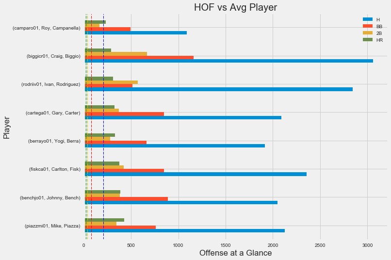

```python
# References used to understand matplotlib library
# http://www.randalolson.com/2014/06/28/how-to-make-beautiful-data-visualizations-in-python-with-matplotlib/
# https://www.dataquest.io/blog/python-data-visualization-libraries/a

import matplotlib.pyplot as plt
import seaborn as sns
%matplotlib inline

# plt.style.available
plt.style.use('fivethirtyeight')

fig, ax = plt.subplots(figsize =(10,8))

playerID_od_c.plot(kind='barh', y=['H', 'BB', '2B', 'HR'], ax=ax)

ax.set(title='HOF vs Avg Player', xlabel = 'Offense at a Glance', ylabel = 'Player')

ax.axvline(x = batting_H, color='b', label='Average', linestyle='--', linewidth=1)

ax.axvline(x = batting_HR, color='g', label='Average', linestyle='--', linewidth=1)

ax.axvline(x = batting_BB, color='r', label='Average', linestyle='--', linewidth=1)

ax.axvline(x = batting_2B, color='y', label='Average', linestyle='--', linewidth=1)

# ax.axvline(x = batting_AB, color='g', label='Average', linestyle='--', linewidth=1)
```

```python
print(batting_groupID['G'].mean())
```

```
318.452562511
```

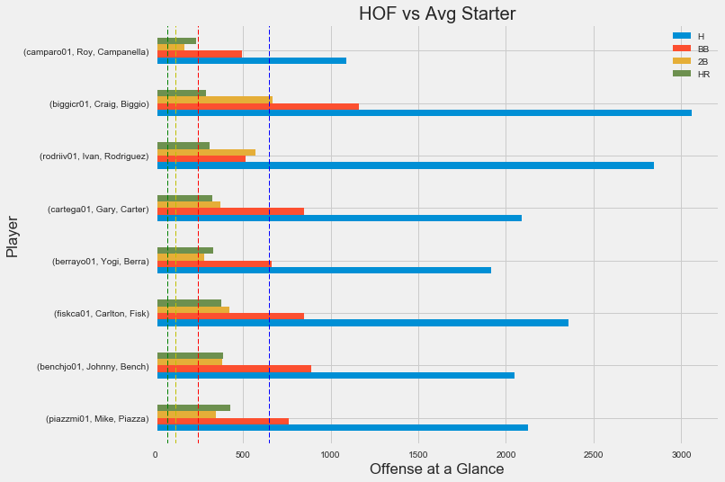

```python
batting_starters = batting_groupID[batting_groupID['G'] > 318]

batting_H = batting_starters['H'].mean()
batting_HR = batting_starters['HR'].mean()
batting_2B = batting_starters['2B'].mean()
batting_BB = batting_starters['BB'].mean()


# plt.style.available
plt.style.use('fivethirtyeight')

fig, ax = plt.subplots(figsize =(10,8))

playerID_od_c.plot(kind='barh', y=['H', 'BB', '2B', 'HR'], ax=ax)

ax.set(title='HOF vs Avg Starter', xlabel = 'Offense at a Glance', ylabel = 'Player')

ax.axvline(x = batting_H, color='b', label='Average', linestyle='--', linewidth=1)

ax.axvline(x = batting_HR, color='g', label='Average', linestyle='--', linewidth=1)

ax.axvline(x = batting_BB, color='r', label='Average', linestyle='--', linewidth=1)

ax.axvline(x = batting_2B, color='y', label='Average', linestyle='--', linewidth=1)
```

## Looking at Starting Catchers performance gives the best idea of how these HOF Players performed compared to their peers.

```python
# creating segment of players that started as catchers

fielding_catcher = fielding_pos[(fielding_pos['POS'] == 'C')]

fielding_catcher = fielding_catcher.drop_duplicates()

batting_starter_catchers = batting_post.merge(fielding_catcher, how = 'left', on='playerID')

batting_starter_catchers = batting_starter_catchers.merge(master, how = 'left', on='playerID')

batting_starter_catchers = batting_starter_catchers[batting_starter_catchers['POS'] == 'C']

# batting_starter_catchers_noindex = batting_starter_catchers

batting_starter_catchers['In_HOF'] = batting_starter_catchers.playerID.isin(hof_catcher_playerID)

print(batting_starter_catchers)
```

```
        playerID  yearID  stint teamID lgID    G   AB   R    H  2B   ...    \
11     astrojo01    1949      1    PHA   AL   55  148  18   36   4   ...
13     bakerbi01    1949      1    SLN   NL   20   30   2    4   1   ...
19     battsma01    1949      1    BOS   AL   60  157  23   38   9   ...
20     bauerha01    1949      1    NYA   AL  103  301  56   82   6   ...
30     berrayo01    1949      1    NYA   AL  116  415  59  115  20   ...
45     boudrlo01    1949      1    CLE   AL  134  475  53  135  20   ...
57     burgesm01    1949      1    CHN   NL   46   56   4   15   0   ...
64     camparo01    1949      1    BRO   NL  130  436  65  125  22   ...
87     coopewa01    1949      1    NY1   NL   42  147  14   31   4   ...
88     coopewa01    1949      2    CIN   NL   82  307  34   86   9   ...
91     crandde01    1949      1    BSN   NL   67  228  21   60  10   ...
117    earlyja01    1949      1    WS1   AL   53  138  12   34   4   ...
119    edwarbr01    1949      1    BRO   NL   64  148  24   31   3   ...
130    evansal01    1949      1    WS1   AL  109  321  32   87  12   ...
```

[output cut: 175 more lines]

```python
batting_starter_catchers = batting_starter_catchers.set_index(['playerID', 'nameFirst', 'nameLast'])

batting_starter_catchers = batting_starter_catchers.groupby(level = ['playerID', 'nameFirst', 'nameLast']).sum()

batting_starter_catchers = batting_starter_catchers[batting_starter_catchers['G'] > 318]

batting_starter_catchers.head()
# batting_starter_catchers.shape
```

| playerID | nameFirst | nameLast | yearID | stint | G | AB | R | H | 2B | 3B | HR | RBI | SB | CS | BB | SO | IBB | HBP | SH | SF | GIDP | In_HOF |
| --- | --- | --- | --- | --- | --- | --- | --- | --- | --- | --- | --- | --- | --- | --- | --- | --- | --- | --- | --- | --- | --- | --- |
| alexaga01 | Gary | Alexander | 15824 | 9 | 432 | 1276 | 169 | 293 | 45 | 11 | 55 | 202.0 | 8.0 | 12.0 | 154 | 381.0 | 12.0 | 5.0 | 4.0 | 19.0 | 34.0 | 0.0 |
| allanan01 | Andy | Allanson | 15921 | 8 | 512 | 1486 | 145 | 357 | 48 | 4 | 16 | 140.0 | 23.0 | 18.0 | 87 | 223.0 | 4.0 | 9.0 | 35.0 | 16.0 | 27.0 | 0.0 |
| allenga01 | Gary | Allenson | 13874 | 7 | 416 | 1061 | 114 | 235 | 49 | 2 | 19 | 131.0 | 3.0 | 7.0 | 130 | 192.0 | 3.0 | 5.0 | 15.0 | 11.0 | 35.0 | 0.0 |
| allenha02 | Hank | Allen | 15755 | 9 | 389 | 881 | 104 | 212 | 27 | 9 | 6 | 57.0 | 15.0 | 9.0 | 49 | 128.0 | 5.0 | 2.0 | 2.0 | 4.0 | 30.0 | 0.0 |
| almonbi01 | Bill | Almon | 33682 | 19 | 1236 | 3330 | 390 | 846 | 138 | 25 | 36 | 296.0 | 128.0 | 60.0 | 250 | 636.0 | 24.0 | 6.0 | 44.0 | 29.0 | 53.0 | 0.0 |

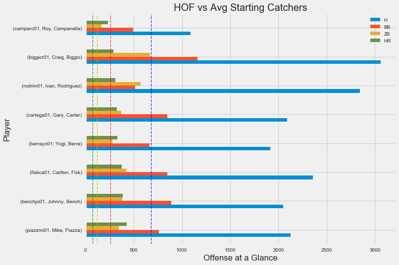

```python
batting_H = batting_starter_catchers['H'].mean()
batting_HR = batting_starter_catchers['HR'].mean()
batting_2B = batting_starter_catchers['2B'].mean()
batting_BB = batting_starter_catchers['BB'].mean()

# plt.style.available
plt.style.use('fivethirtyeight')

fig, ax = plt.subplots(figsize =(10,8))

playerID_od_c.plot(kind='barh', y=['H', 'BB', '2B', 'HR'], ax=ax)

ax.set(title='HOF vs Avg Starting Catchers', xlabel = 'Offense at a Glance', ylabel = 'Player')

ax.axvline(x = batting_H, color='b', label='Average', linestyle='--', linewidth=1)

ax.axvline(x = batting_HR, color='g', label='Average', linestyle='--', linewidth=1)

ax.axvline(x = batting_BB, color='r', label='Average', linestyle='--', linewidth=1)

ax.axvline(x = batting_2B, color='y', label='Average', linestyle='--', linewidth=1)
```